# Project: #WeRateDogs[Wrangle and Analyze Data]

**Introduction**

WeRateDogs @dog_rates is a Twitter account that rates people's dogs with a humorous comment about the dog. It contained the dog stages, ratings, favorite, retweet counts etc of different tweets.

Comparing the mean of the favorite counts of the various dogs, floofer had the highest mean of 22929.00, and pupper had the least favorite count mean of 7136.28.

Retweet counts of the various dogs, floofer had the highest and pupper had the least favorite count mean of 2327.79.

There is an increase in the retweet count as the rating numerator increased with about 15 being the heighest.

Also there is an increase in the favorite count as the rating numerator increased with about 15 being the heighest.

**Analysing and Visualising the data**

The dog stage was used for analysis.

1 Pupper had the highest number of dogs while floofer had the least.

Fig 1: Dog stages value count.

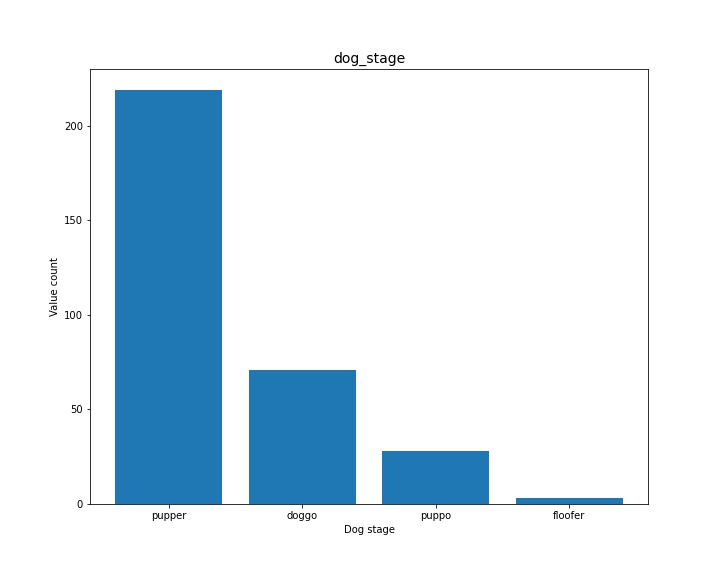

2 Floofer had the highest mean favorite count and pupper had the least. See chart below.

Fig 2: Dog stages vs favorite counts.

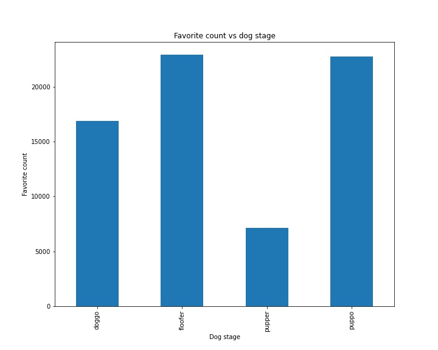

3 Floofer had the highest mean and pupper had the least retweet count.

Fig 3: Dog stages vs retweet counts.

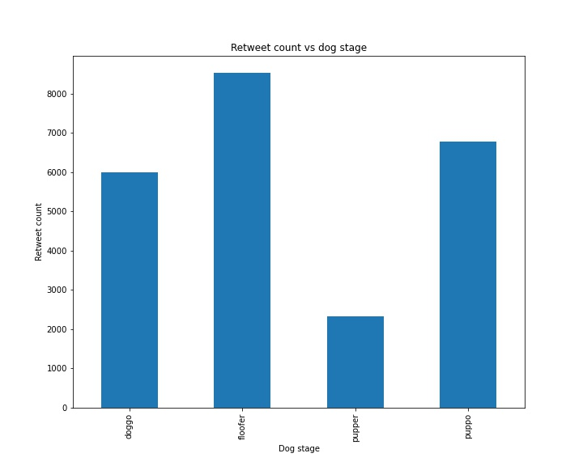

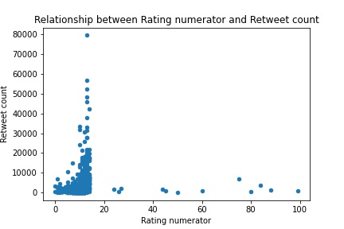

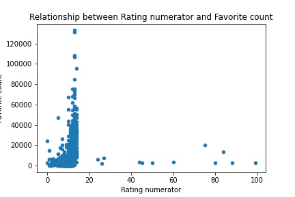

**Conclusion**